# ST443 Group Project - Task 1

# Random Forest

The randomForest() function fits an ensemble of decision trees using the Random Forest algorithm. It builds multiple decision trees (ntree = 500 in this case) by bootstrapping (sampling with replacement) from the training data. Each tree is grown using a random subset of features (mtry = round(sqrt(p))). This randomness helps reduce overfitting and increases the model’s ability to generalize to unseen data. The argument `importance = TRUE` means that the model will calculate and store the importance of each feature, which can be useful for understanding which predictors are most influential in predicting the target variable. Tuning: tuned with different ntrees (100, 150, 250, 500) and found 500 was the optimal.

```r
library(randomForest)

# Train Random Forest with mtry = sqrt(number of predictors)
p <- ncol(train_data1) - 1  # Number of predictors (excluding the label column)
train_data1$label <- as.factor(train_data1$label)
rf_model <- randomForest(label ~ ., data = train_data1, mtry = round(sqrt(p)), ntree = 500, importance = TRUE)
```

```r
# Predictions on the test data
rf_predictions <- predict(rf_model, test_data1)

# Evaluating the model with a confusion matrix
conf_matrix_rf <- confusionMatrix(rf_predictions, as.factor(test_data1$label))

# Extracting specific performance metrics
accuracy_rf <- conf_matrix_rf$overall['Accuracy']
balanced_accuracy_rf <- conf_matrix_rf$byClass['Balanced Accuracy']
f1_score_rf <- conf_matrix_rf$byClass['F1']
```

```r
# Getting predicted probabilities for "TREG" class
rf_probs <- predict(rf_model, test_data1, type = "prob")[, 2]
```

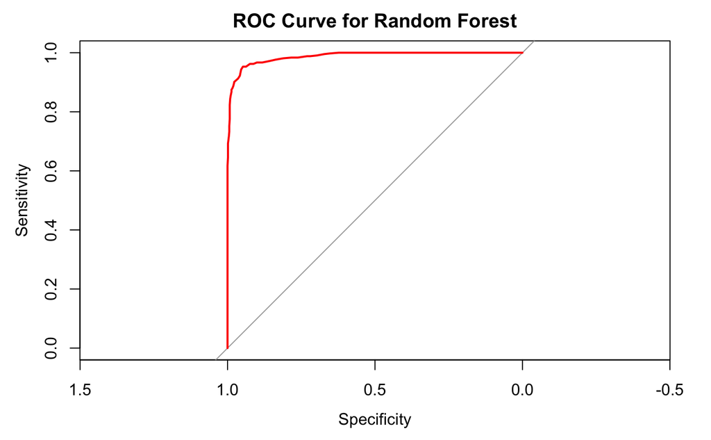

```r
# Create ROC curve
roc_curve_rf <- roc(test_data1$label, rf_probs)
plot(roc_curve_rf, col = "red", main = "ROC Curve for Random Forest")
```

```r
# Calculate AUC
auc_value_rf <- auc(roc_curve_rf)

# Calculate test error
rf_test_error <- mean(rf_predictions != test_data1$label)
```

```r
cat("Random Forest Evaluation Summary:\n")
```

```
Random Forest Evaluation Summary:
```

```r
cat("Accuracy:", round(accuracy_rf, 3), "\n")
```

```
Accuracy: 0.943
```

```r
cat("Balanced Accuracy:", round(balanced_accuracy_rf, 3), "\n")
```

```
Balanced Accuracy: 0.931
```

```r
cat("F1 Score:", round(f1_score_rf, 3), "\n")
```

```
F1 Score: 0.955
```

```r
cat("AUC:", round(auc_value_rf, 3), "\n")
```

```
AUC: 0.987
```

```r
cat("Test Error (Random Forest):", round(rf_test_error, 3), "\n")
```

```
Test Error (Random Forest): 0.057
```

### K-NN

The knn() function in R is used to perform classification using the k-Nearest Neighbors algorithm. In this model, the prediction for a test observation is based on the majority class of the ‘k’ nearest training samples. The algorithm computes the distance (Euclidean) between each test point and all training points in the feature space, selects the ‘k’ nearest neighbors, and assigns the most frequent class label from these neighbors as the predicted label for the test point. Tuning: found that k=15 is the optimal k.

```r
train_X <- as.matrix(train_data1[, -1]) # Excluding the label column
test_X <- as.matrix(test_data1[, -1])

# Create vectors for labels (Y)
train_Y <- as.factor(train_data1$label)
test_Y <- as.factor(test_data1$label)
```

```r
## TUNING - do not need to run ##

cv_control <- trainControl(method = "cv", number = 10)

# Tuning the knn to try k values from 1 to 20
knn_tune <- train(train_X, train_Y, method = "knn", trControl = cv_control,
                  tuneGrid = expand.grid(k = 1:20))
optimal_k <- knn_tune$bestTune$k
print(optimal_k)

# optimal k is 15
```

```r
# Train and predict using k-NN with k = 15
optimal_k <- 15

knn_predictions <- knn(train_X, test_X, train_Y, k = optimal_k)

# Confusion matrix
conf_matrix_knn <- confusionMatrix(as.factor(knn_predictions), as.factor(test_Y))

# Calculate Accuracy, Balanced Accuracy, F1 Score
accuracy_knn <- conf_matrix_knn$overall["Accuracy"]
balanced_accuracy_knn <- conf_matrix_knn$byClass["Balanced Accuracy"]
f1_score_knn <- conf_matrix_knn$byClass["F1"]
```

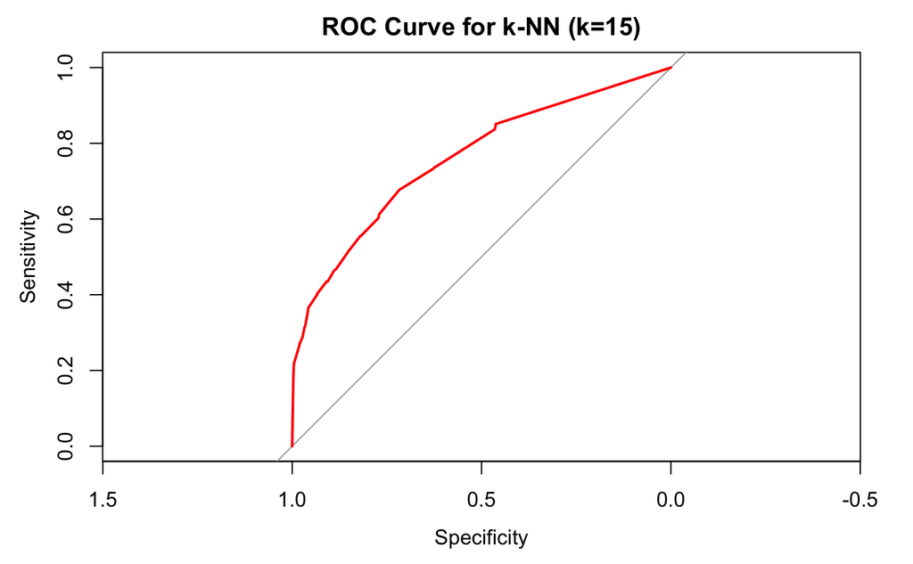

```r
# Calculate test error
knn_test_error <- mean(knn_predictions != test_Y)

# AUC Calculation
knn_probabilities <- knn(train_X, test_X, train_Y, k = optimal_k, prob = TRUE)  # Use the prob argument
knn_probabilities <- ifelse(knn_predictions == "TREG", attr(knn_probabilities, "prob"), 1 - attr(knn_probabilities, "prob"))

knn_roc_obj <- roc(as.numeric(test_Y), knn_probabilities)
auc_knn <- auc(knn_roc_obj)

# Plot ROC curve
plot(knn_roc_obj, col = "red", main = "ROC Curve for k-NN (k=15)")
```

```r
cat("KNN Classifiers Summary:\n")
```

```
KNN Classifiers Summary:
```

```r
cat("Accuracy:", round(accuracy_knn, 3), "\n")
```

```
Accuracy: 0.724
```

```r
cat("Balanced Accuracy:", round(balanced_accuracy_knn, 3), "\n")
```

```
Balanced Accuracy: 0.671
```

```r
cat("F1 Score:", round(f1_score_knn, 3), "\n")
```

```
F1 Score: 0.801
```

```r
cat("AUC:", round(auc_knn, 3), "\n")
```

```
AUC: 0.759
```

```r
cat("Test Error (k-NN):", round(knn_test_error, 3), "\n")
```

```
Test Error (k-NN): 0.276
```